# Predicting the quality of physical exercise

Sebastian Stoll

16 Aug 2015

# Synopsis

The execution of physical exercises using precise and accentuated movements is important to reach a maximal training effect and to prevent injuries. In this project I am going a to build a classification model which predicts the quality of an exercise based on accelerometers attached to the belt, forearm and dumbell of probands. The resulting random forest based model that was created can predict the correct class with almost 100% accuracy.

# Loading the Data

The training data for predicting the quality of barbell lifts was taking from the project page of the Coursera Machine Learning course and placed into a local folder. More information about the dataset and related research can be found here: http://groupware.les.inf.puc-rio.br/har#weight_lifting_exercises

Both files are in csv format and can be loaded without any modifications:

```r
pmlTestingFileName <- '/Users/sebastian/r+d/coursera/machine learning dss/course project/pml-testing.csv'
pmlTrainingFileName <- '/Users/sebastian/r+d/coursera/machine learning dss/course project/pml-Training.csv'

pmlTesting <- read.csv(file = pmlTestingFileName, header = TRUE)
pmlTraining <- read.csv(file = pmlTrainingFileName, header = TRUE)
```

# Exploratory Data Analysis

To get a better idea of the different variables and their influence on the quality of an exercise I am using feature plots.

Feature plots of total accelleration values:

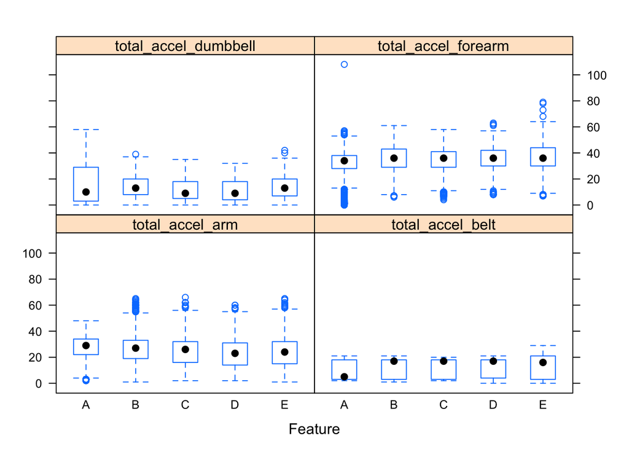

Feature plots of pitch, yaw, roll per body part:

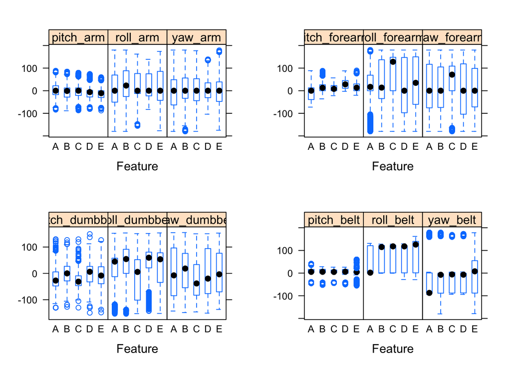

Feature plots for the gyros values per body part:

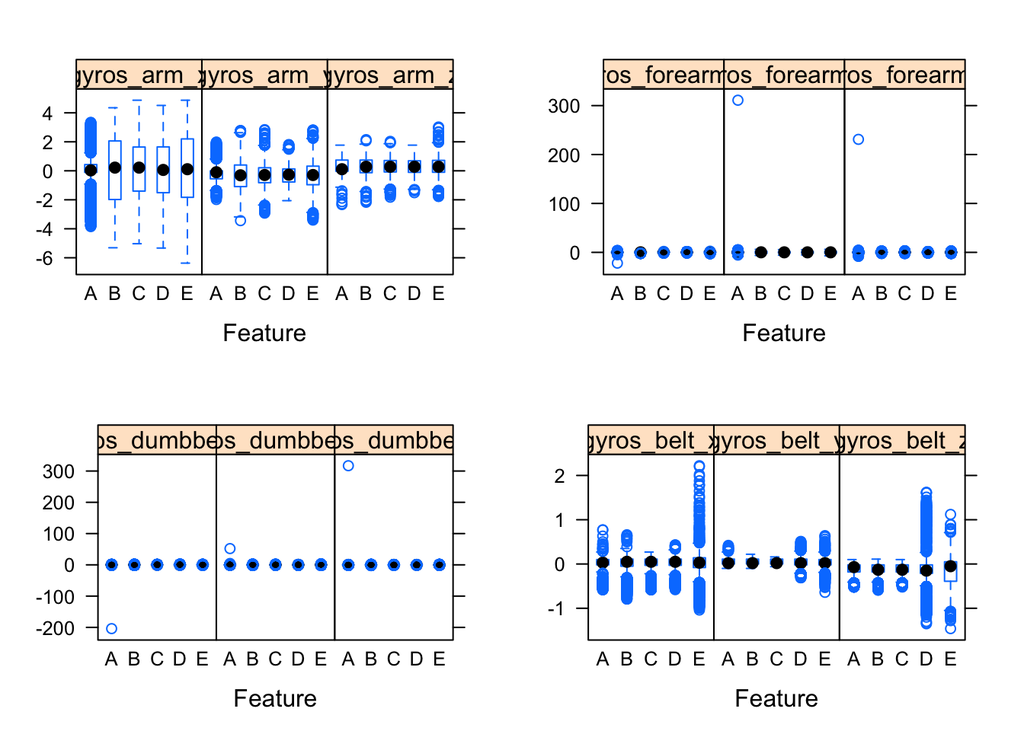

Furthermore I am checking for columns with more than 90% NAs to exclude them later in the preprocessing of the data.

```r
naCount <- colMeans(is.na(pmlTraining))
naCount[naCount>0.90]
```

```
##            max_roll_belt           max_picth_belt            min_roll_belt
##                0.9793089                0.9793089                0.9793089
##           min_pitch_belt      amplitude_roll_belt     amplitude_pitch_belt
##                0.9793089                0.9793089                0.9793089
##     var_total_accel_belt            avg_roll_belt         stddev_roll_belt
##                0.9793089                0.9793089                0.9793089
##            var_roll_belt           avg_pitch_belt        stddev_pitch_belt
##                0.9793089                0.9793089                0.9793089
##           var_pitch_belt             avg_yaw_belt          stddev_yaw_belt
##                0.9793089                0.9793089                0.9793089
##             var_yaw_belt            var_accel_arm             avg_roll_arm
##                0.9793089                0.9793089                0.9793089
##          stddev_roll_arm             var_roll_arm            avg_pitch_arm
##                0.9793089                0.9793089                0.9793089
##         stddev_pitch_arm            var_pitch_arm              avg_yaw_arm
##                0.9793089                0.9793089                0.9793089
##           stddev_yaw_arm              var_yaw_arm             max_roll_arm
##                0.9793089                0.9793089                0.9793089
##            max_picth_arm              max_yaw_arm             min_roll_arm
##                0.9793089                0.9793089                0.9793089
##            min_pitch_arm              min_yaw_arm       amplitude_roll_arm
##                0.9793089                0.9793089                0.9793089
##      amplitude_pitch_arm        amplitude_yaw_arm        max_roll_dumbbell
##                0.9793089                0.9793089                0.9793089
##       max_picth_dumbbell        min_roll_dumbbell       min_pitch_dumbbell
##                0.9793089                0.9793089                0.9793089
##  amplitude_roll_dumbbell amplitude_pitch_dumbbell       var_accel_dumbbell
##                0.9793089                0.9793089                0.9793089
##        avg_roll_dumbbell     stddev_roll_dumbbell        var_roll_dumbbell
##                0.9793089                0.9793089                0.9793089
##       avg_pitch_dumbbell    stddev_pitch_dumbbell       var_pitch_dumbbell
##                0.9793089                0.9793089                0.9793089
##         avg_yaw_dumbbell      stddev_yaw_dumbbell         var_yaw_dumbbell
##                0.9793089                0.9793089                0.9793089
##         max_roll_forearm        max_picth_forearm         min_roll_forearm
##                0.9793089                0.9793089                0.9793089
##        min_pitch_forearm   amplitude_roll_forearm  amplitude_pitch_forearm
##                0.9793089                0.9793089                0.9793089
##        var_accel_forearm         avg_roll_forearm      stddev_roll_forearm
##                0.9793089                0.9793089                0.9793089
##         var_roll_forearm        avg_pitch_forearm     stddev_pitch_forearm
##                0.9793089                0.9793089                0.9793089
##        var_pitch_forearm          avg_yaw_forearm       stddev_yaw_forearm
##                0.9793089                0.9793089                0.9793089
##          var_yaw_forearm
##                0.9793089
```

# Building the Classification Model

When building my classification model I address the data preprocessing, feature and model selection and out of sample error in separate subsections.

## Data Preprocessing

The preprocessing I am doing aims at cleaning up the training set so that all remaining features are potential and usefull predictors.

First we can remove the index and the name of the user from which the data originated as this will be not revelant for our model. The timestamps are also not of interest because they just track when the motion was recorded but not how. The window fields are excluded because they are just tracked as part of the trials.

```r
pmlTrainingPreprocessed <- select(pmlTraining, -X, -user_name, -raw_timestamp_part_1, -raw_timestamp_part_2,-cvtd_timestamp,-new_window,-num_window)
```

All variables including standard deviations or variances are excluded as well because they are usually near zero variance predictors:

```r
columnNames <- names(pmlTrainingPreprocessed)
removableColumns <- c(columnNames[grepl("var*", columnNames)],columnNames[grepl("avg*", columnNames)],columnNames[grepl("std*", columnNames)])
pmlTrainingPreprocessed <- pmlTrainingPreprocessed[, !(names(pmlTrainingPreprocessed) %in% removableColumns)]
```

To identify which of the remaining features might be useful for predictions, features that are near zero variance features are being excluded:

```r
nsv <- nearZeroVar(pmlTrainingPreprocessed, saveMetrics=TRUE)
pmlTrainingPreprocessed <- pmlTrainingPreprocessed[, !(names(pmlTrainingPreprocessed) %in% names(pmlTrainingPreprocessed)[nsv$nzv])]
```

While having an exploratory look at the data it also surfaced that some columns contain lots of NAs. To impute is not an option because about 95% in those columns are NAs, so they will be exluced as well.

```r
hasMissingValues = function(columnId, df) {
    sum(is.na(df[,columnId]))
}
columnsWithNA <- unlist(lapply(1:72, hasMissingValues, pmlTrainingPreprocessed)) > 0
pmlTrainingFinal <- pmlTrainingPreprocessed[, !(names(pmlTrainingPreprocessed) %in% names(pmlTrainingPreprocessed)[columnsWithNA])]
```

## Selecting a Classification Algorithm

There are several possible machine learning algorithms that could be used predicting the classe variable indicating the quality of a barbell movement. E.g. bagging, tree or random forests.

I include all features into the model that are left after the preprocessing:

```r
pmlModel <- train(classe ~ ., data=pmlTrainingFinal, method="rf", trControl = trainControl(method = "oob", number = 10))
pmlModel$finalModel
```

```
##
## Call:
##  randomForest(x = x, y = y, mtry = param$mtry)
##                Type of random forest: classification
##                      Number of trees: 500
## No. of variables tried at each split: 2
##
##         OOB estimate of  error rate: 0.42%
## Confusion matrix:
##      A    B    C    D    E  class.error
## A 5578    2    0    0    0 0.0003584229
## B   12 3781    4    0    0 0.0042138530
## C    0   17 3404    1    0 0.0052600818
## D    0    0   37 3176    3 0.0124378109
## E    0    0    0    6 3601 0.0016634322
```

## Out of Sample Error

The out of sample or generalization error describes the error rate when our model is being applied to a new data set.

```r
missClass = function(values,predictions) { sum(predictions != values)/length(values) }
hitClass = function(values,predictions) { sum(predictions == values)/length(values) }
missClass(pmlTraining$classe, predict(pmlModel, newdata = pmlTrainingFinal))
```

```
## [1] 0
```

```r
hitClass(pmlTraining$classe, predict(pmlModel, newdata = pmlTrainingFinal))
```

```
## [1] 1
```

The results show that we are close to the OOB estimate of the error rate and correctly predict each outcome.

# Summary

I created a model based on random forests that can predict with an almost perfect score if a barbell movement was of high quality or not. Exploratory data analysis and pre-processing of the data was used to shrink the number of features that are part of the model and to increase its accuracy.